### Independent sample t-test:

Assumptions

- Independence of the observations. There is no relationship between the observations in each group.
- No significant outliers in the groups
- the two groups of samples should be normally distributed.
- If using the Student’s t-test, the variances of the two groups should not be significantly different. This assumption is relaxed in the Welch’s t-test.

#### Example: Gentoo vs. Adelie body mass

Let’s use the independent sample t-test to see if there is a significant difference in the mean body mass of Gentoo penguins vs. Adelie penguins:

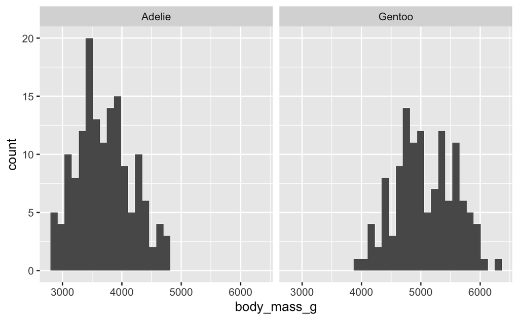

```r
# Simplify the dataset to what we need
data_for_t_test = penguins %>%
  filter(species %in% c("Gentoo", "Adelie"),
         !is.na(body_mass_g)) %>%
  select(species, body_mass_g) %>%
  droplevels() # This removes the "Chinstrap" level from the species factor

# Calculate summary stats
data_for_t_test %>%
  group_by(species) %>%
  summarize(mean=mean(body_mass_g), sd=sd(body_mass_g))
## `summarise()` ungrouping output (override with `.groups` argument)
## # A tibble: 2 x 3
##   species  mean    sd
##   <fct>   <dbl> <dbl>
## 1 Adelie  3701.  459.
## 2 Gentoo  5076.  504.

# Plot a quick histogram:
ggplot(aes(x=body_mass_g), data=data_for_t_test) +
  geom_histogram() +
  facet_wrap(~species)
## `stat_bin()` using `bins = 30`. Pick better value with `binwidth`.
```

```r
# Look for the presence of outliers
data_for_t_test %>%
  group_by(species) %>%
  identify_outliers(body_mass_g)
```

```
## [1] species     body_mass_g is.outlier  is.extreme
## <0 rows> (or 0-length row.names)
```

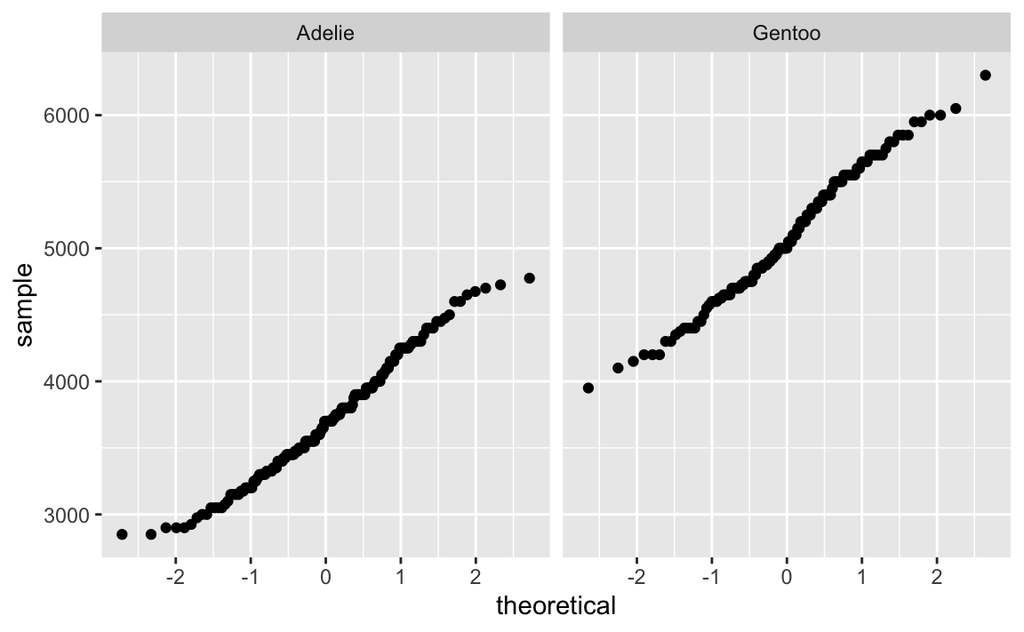

```r
# Check normality assumption with a qqplot:
ggplot(data_for_t_test) +
  stat_qq(aes(sample=body_mass_g)) +
  facet_wrap(~species)
```

```r
# Check equality of variances
data_for_t_test %>% levene_test(body_mass_g ~ species)
```

```
## # A tibble: 1 x 4
##     df1   df2 statistic     p
##   <int> <int>     <dbl> <dbl>
## 1     1   272      1.99 0.159
```

We are examining the distribution of body mass observations for Gentoo and Adelie penguins, and the histograms looked normal. No outliers were found. The Q-Q plots looked fine - the data fall along the 1:1 line. Levene’s test checks for equality of variances, and since p>0.05, we accept the null hypothesis that the variances are equal. That means we can use the Student’s t-test if we want (we’ll probably be “safe” and use Welch’s t-test anyway). Whew. Stats are exhuasting, right?

Now let’s actually run the independent sample t-test.

```r
# Base R version:
t.test(data_for_t_test$body_mass_g ~ data_for_t_test$species)
```

```
##
##  Welch Two Sample t-test
##
## data:  data_for_t_test$body_mass_g by data_for_t_test$species
## t = -23.386, df = 249.64, p-value < 2.2e-16
## alternative hypothesis: true difference in means is not equal to 0
## 95 percent confidence interval:
##  -1491.183 -1259.525
## sample estimates:
## mean in group Adelie mean in group Gentoo
##             3700.662             5076.016
```

```r
# dplyr-friendly version:
data_for_t_test %>%
  t_test(body_mass_g ~ species)
```

```
## # A tibble: 1 x 8
##   .y.         group1 group2    n1    n2 statistic    df        p
## * <chr>       <chr>  <chr>  <int> <int>     <dbl> <dbl>    <dbl>
## 1 body_mass_g Adelie Gentoo   151   123     -23.4  250. 7.71e-65
```

```r
# Calculate the effect size:
data_for_t_test %>%  cohens_d(body_mass_g ~ species)
```

```
## # A tibble: 1 x 7
##   .y.         group1 group2 effsize    n1    n2 magnitude
## * <chr>       <chr>  <chr>    <dbl> <int> <int> <ord>
## 1 body_mass_g Adelie Gentoo   -2.85   151   123 large
```

So we can reject the null hypothesis that the means are equal, and accept the alternative hypothesis. Adelie body mass is significantly lower than Gentoo body mass (Welch’s t-test, p<0.001).

If we had wanted to run a Student’s t-test, we could have just included a parameter in the t.test function `var.equal=TRUE`. I’m also showing both the base R `t.test()` and the dplyr-friendly `t_test` from the `rstatix` package. A nice thing about `t.test()` is that there is a lot of hand-holding in the results output (who doesn’t love having their hand held in statistics?). An advantage of `t_test()` is that the output is in a simple table, so tranferring these results into a report is easier, especially if you have a bunch of t-tests to do and you can build a data frame with a new test result in each row.

### Paired sample t-test:

The paired sample t-test is used to compare the means of two related groups of samples. Put into another words, it’s used in a situation where you have two pairs of values measured for the same samples. For example, you might want to compare the average weight of 20 sea urchins before and after some experimental treatment. The paired t-test can be used to compare the mean weights before and after treatment.

Assumptions:

- No significant outliers in the differences between groups
- The difference of pairs should follow a normal distribution.

We don’t have any good exmaples of paired data in our penguins dataset. However, conducting the paired t-test looks almost identical to the independent sample t-test, except that you test your assumptions for outliers and normality on the difference between the paired data (i.e. for each individual urchin, the difference is the weight before treatment minus the weight after treatment). Then run `t_test()` with the parameter `paired=TRUE`.

### Note on assumptions:

**Assessing equality of variances:** Homogeneity of variances can be checked using the Levene’s test. Note that, by default, the t_test() function does not assume equal variances; instead of the standard Student’s t-test, it uses the Welch t-test by default, which is the considered the safer one. To use Student’s t-test, set var.equal = TRUE. The two methods give very similar results unless both the group sizes and the standard deviations are very different.

In the situations where the assumptions are violated, non-parametric tests, such as Wilcoxon test, are recommended.

### Acknowledgements

Although we used our beloved penguin data, the structure of this lesson was inspired by Data Novia:

https://www.datanovia.com/en/lessons/t-test-in-r/